# Time Series (Final Report)

Hwang Seong-Yun

2021 12 8

## Loading packages

```r
library(sarima)
```

```r
library(ggplot2)
library(forecast)
library(data.table)
library(gridExtra)
library(fUnitRoots)
library(portes)
library(lmtest)
library(expsmooth)
library(fma)
library(fpp2)
```

## 1.사용할 데이터 : mcopper

```r
mcopper
```

```
##         Jan    Feb    Mar    Apr    May    Jun    Jul    Aug    Sep    Oct
## 1960  255.2  259.7  249.3  258.0  244.3  246.8  250.6  241.3  231.0  218.7
## 1961  216.6  220.1  221.7  225.6  238.6  232.8  226.1  227.2  225.8  225.0
## 1962  226.8  231.3  231.1  230.6  230.5  230.4  230.4  230.4  230.4  230.6
## 1963  230.6  230.6  230.6  230.6  230.6  230.6  230.6  230.6  230.6  230.6
## 1964  234.2  247.8  266.1  307.7  295.8  288.8  305.4  356.9  415.0  485.1
## 1965  356.7  419.2  440.6  480.5  490.8  466.1  404.0  431.6  473.5  500.1
## 1966  599.0  668.7  668.7  679.9  592.8  604.8  559.5  426.4  402.4  454.9
## 1967  443.7  435.4  391.8  354.9  369.5  362.3  355.9  372.7  378.3  406.3
## 1968  586.4  715.8  708.0  522.4  456.5  473.0  439.9  439.9  462.3  449.7
## 1969  523.8  535.0  532.4  578.1  579.6  617.0  605.4  669.0  657.6  647.4
## 1970  677.2  690.1  730.4  725.2  665.9  607.0  567.8  527.5  519.3  475.8
## 1971  420.7  424.9  476.5  521.2  464.1  447.2  464.4  451.0  427.5  417.7
## 1972  418.9  426.9  442.2  433.5  423.3  412.4  423.2  427.0  434.2  428.7
## 1973  474.7  511.8  610.2  638.8  613.0  678.4  795.4  843.5  799.6  849.6
```

[output cut: 81 more lines]

### 1) 변수변환이 필요한지를 설명하고, 필요하다면 적절한 변수 변환을 하여라.

- 먼저 본 데이터에 대한 plot을 그려보면 다음과 같다.

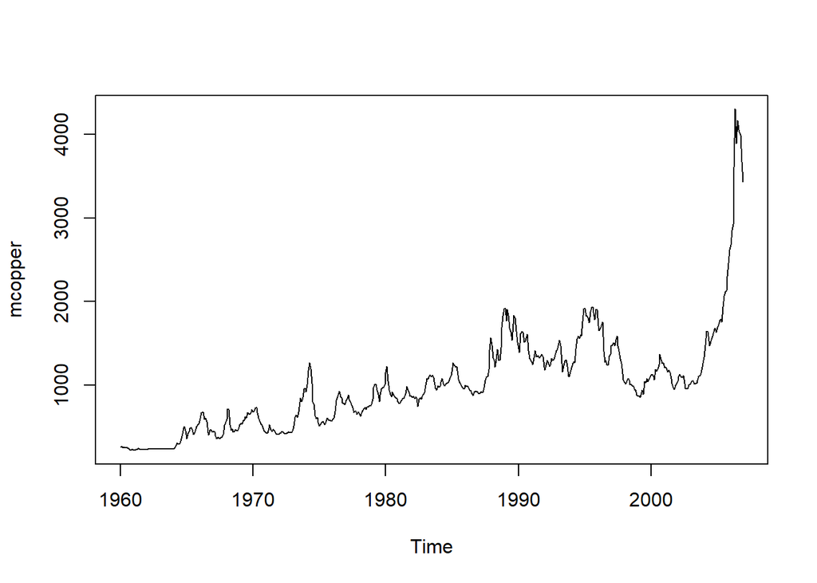

```r
plot(mcopper)
```

- 그래프를 보면 시간이 지날수록 변동성이 더 커지는 경향이 있음을 알 수 있다. 보통 이러한 경우에는 log변환을 생각할 수 있지만 boxcox 변환을 통해서 적절한 변환을 실시해보도록 한다. 이는 다음과 같이 할 수 있다.

```r
mcopper_trans <- BoxCox(mcopper,lambda=BoxCox.lambda(mcopper))
BoxCox.lambda(mcopper)
```

```
## [1] 0.1919047
```

- 변환결과, 적절한 모수 lambda는 약 0.1919로 산출되었고 이를 통하여 변환된 결과에 대한 plot을 그려보면 다음과 같다.

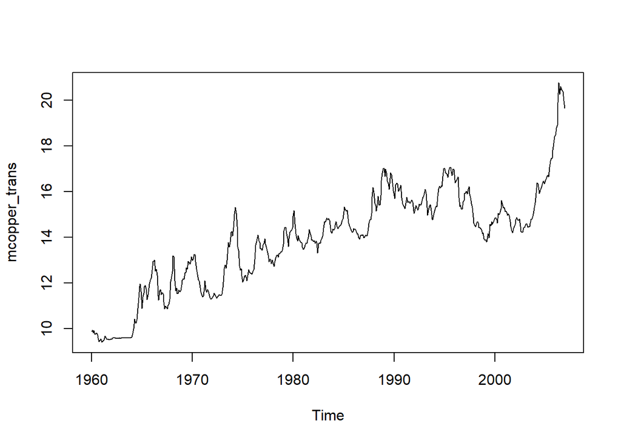

```r
plot(mcopper_trans)
```

- boxcox 변환을 통해 변동성을 어느정도 줄인 것으로 판단된다.

### 2) auto.arima 를 이용하여 예측 모형을 적합하여라. (형태 : ARIMA(p.d.q)(P,D,Q)s , 모수 추정값)

- 1)에서 변환한 결과에 대해 `auto.arima` 함수를 이용하여 모형을 적합하면 다음과 같다.

```r
auto.arima(mcopper_trans, trace=T, ic='aic')
```

```
##
##  Fitting models using approximations to speed things up...
##
##  ARIMA(2,1,2)(1,0,1)[12] with drift         : -66.32021
##  ARIMA(0,1,0)            with drift         : -13.82248
##  ARIMA(1,1,0)(1,0,0)[12] with drift         : -62.06849
##  ARIMA(0,1,1)(0,0,1)[12] with drift         : -82.25982
##  ARIMA(0,1,0)                               : -12.82906
##  ARIMA(0,1,1)            with drift         : -83.13952
##  ARIMA(0,1,1)(1,0,0)[12] with drift         : -73.91207
##  ARIMA(0,1,1)(1,0,1)[12] with drift         : -71.92506
##  ARIMA(1,1,1)            with drift         : -80.30584
##  ARIMA(0,1,2)            with drift         : -81.16609
##  ARIMA(1,1,0)            with drift         : -71.41152
##  ARIMA(1,1,2)            with drift         : -78.27629
##  ARIMA(0,1,1)                               : -83.33279
##  ARIMA(0,1,1)(1,0,0)[12]                    : -74.05872
##  ARIMA(0,1,1)(0,0,1)[12]                    : -82.603
##  ARIMA(0,1,1)(1,0,1)[12]                    : -72.07316
##  ARIMA(1,1,1)                               : -80.55931
##  ARIMA(0,1,2)                               : -81.33929
##  ARIMA(1,1,0)                               : -71.94456
##  ARIMA(1,1,2)                               : -80.62448
##
##  Now re-fitting the best model(s) without approximations...
##
##  ARIMA(0,1,1)                               : -86.0969
##
##  Best model: ARIMA(0,1,1)
```

```
## Series: mcopper_trans
## ARIMA(0,1,1)
##
## Coefficients:
##          ma1
##       0.3720
## s.e.  0.0388
##
## sigma^2 estimated as 0.04997:  log likelihood=45.05
## AIC=-86.1   AICc=-86.08   BIC=-77.43
```

- 적합결과 AIC 기준으로 모수의 값이 $\hat{\theta}=-0.3720$인 ARIMA(0,1,1) 모형을 가장 좋은 모형으로 제시하고 있다. 이 모형에 대한 로그가능도값은 45.05이다.

### 3) 2)번 모형을 제외한 다른 후보 모형을 선택하여 적합하여라. (형태 : ARIMA(p.d.q)(P,D,Q)s , 모수 추정값)

- 모형을 식별하기 위해 1)을 통해 변환된 자료에 대해 ACF와 PACF를 그려보도록 하자.

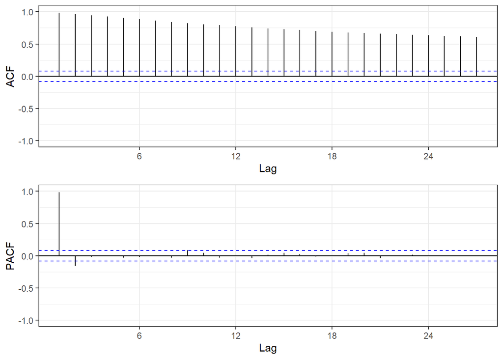

```r
p1 <- ggAcf(mcopper_trans) +
  theme_bw() + ylim(-1,1) +
  theme(plot.title = element_blank())
p2 <- ggPacf(mcopper_trans) +
  theme_bw() +ylim(-1,1) +
  theme(plot.title = element_blank())
grid.arrange(p1, p2, nrow=2)
```

- ACF를 보면 감소는 하고 있지만 굉장히 느린 속도로 감소하고 있음을 알 수 있다. 즉 정상시계열로 만들기 위해 차분이 필요함을 알 수 있다. 우선 Dickey-Fuller unit root test를 통해 단위근의 존재 여부를 판단해보자.

```r
adfTest(mcopper_trans, lags = 0, type = "c")
```

```
##
## Title:
##  Augmented Dickey-Fuller Test
##
## Test Results:
##   PARAMETER:
##     Lag Order: 0
##   STATISTIC:
##     Dickey-Fuller: -0.5824
##   P VALUE:
##     0.843
##
## Description:
##  Thu Dec 09 19:54:01 2021 by user: HSY
```

```r
adfTest(mcopper_trans, lags = 1, type = "c")
```

```
##
## Title:
##  Augmented Dickey-Fuller Test
##
## Test Results:
##   PARAMETER:
##     Lag Order: 1
##   STATISTIC:
##     Dickey-Fuller: -1.3332
##   P VALUE:
##     0.5623
##
## Description:
##  Thu Dec 09 19:54:01 2021 by user: HSY
```

```r
adfTest(mcopper_trans, lags = 2, type = "c")
```

```
##
## Title:
##  Augmented Dickey-Fuller Test
##
## Test Results:
##   PARAMETER:
##     Lag Order: 2
##   STATISTIC:
##     Dickey-Fuller: -1.0597
##   P VALUE:
##     0.6646
##
## Description:
##  Thu Dec 09 19:54:01 2021 by user: HSY
```

- 위의 결과 모두 유의확률의 값이 유의수준 $\alpha=0.05$보다 큰 값이므로 단위근이 존재한다는 결론을 주고 있다. 이에 따라 시차 1에서 차분을 하고 그 결과에 대한 그림을 그리면 다음과 같다.

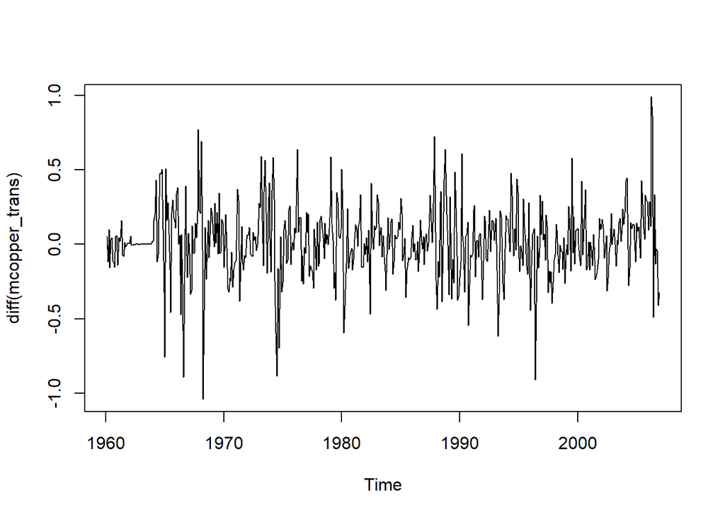

```r
plot(diff(mcopper_trans))
```

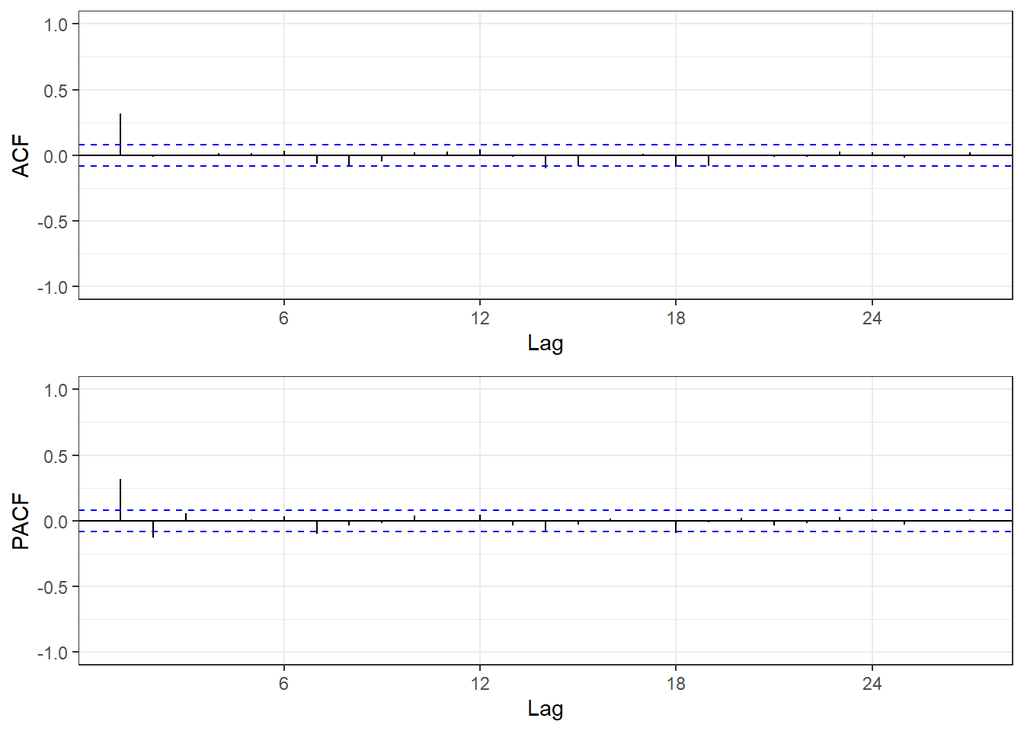

```r
p1 <- ggAcf(diff(mcopper_trans)) +
  theme_bw() + ylim(-1,1) +
  theme(plot.title = element_blank())
p2 <- ggPacf(diff(mcopper_trans)) +
  theme_bw() +ylim(-1,1) +
  theme(plot.title = element_blank())
grid.arrange(p1, p2, nrow=2)
```

```r
fit1 <- arima(mcopper_trans, order = c(1,1,1))
fit1
```

```
##
## Call:
## arima(x = mcopper_trans, order = c(1, 1, 1))
##
## Coefficients:
##           ar1     ma1
##       -0.0092  0.3797
## s.e.   0.1053  0.0961
##
## sigma^2 estimated as 0.04988:  log likelihood = 45.05,  aic = -84.1
```

- 분석결과 모수의 값이 $\hat{\phi}=-0.0092, \hat{\theta}=-0.3797$인 ARIMA(1,1,1) 모형을 제시하고 있으며, 이 모형에 대한 로그가능도값은 45.05이다.

### 4) 2),3)번 모형 중 어떤 모형일 더 적절한지 설명하여라.

- 2)와 3)에서 제시한 두가지 모형에 대한 로그가능도값이 거의 비슷하다. 이 중 간단한 모형은 2)에서 적합한 모형이므로 최종적으로 boxcox 변환이 이루어진 데이터에 대해 ARIMA(0,1,1) 모형을 최적의 모형으로 선정하도록 한다.

### 5) 4)에서 선택한 모형을 이용하여 잔차검정을 시행하여라.

- 적합한 모형에 대하여 잔차검정을 진행한다면 다음과 같이 할 수 있다. 우선 잔차에 대한 plot과 ACF, PACF를 살펴보면 다음과 같다.

```r
fit_final <- arima(mcopper_trans, order=c(0,1,1))
fit_final
```

```
##
## Call:
## arima(x = mcopper_trans, order = c(0, 1, 1))
##
## Coefficients:
##          ma1
##       0.3720
## s.e.  0.0388
##
## sigma^2 estimated as 0.04988:  log likelihood = 45.05,  aic = -86.1
```

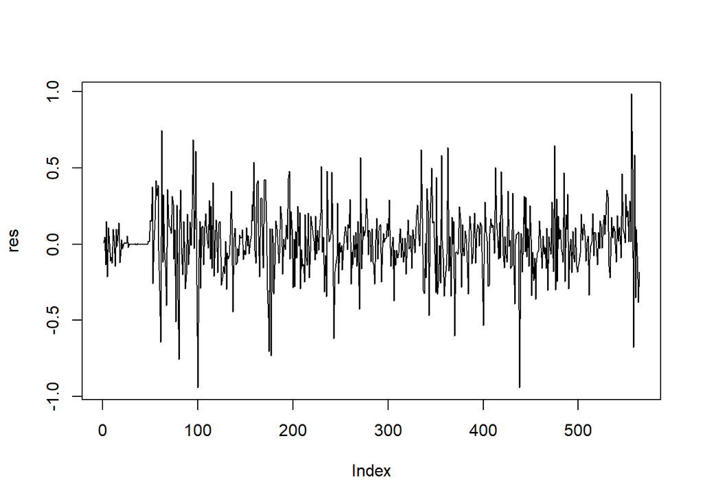

```r
res <- as.numeric(resid(fit_final))
plot(res,type='l')
```

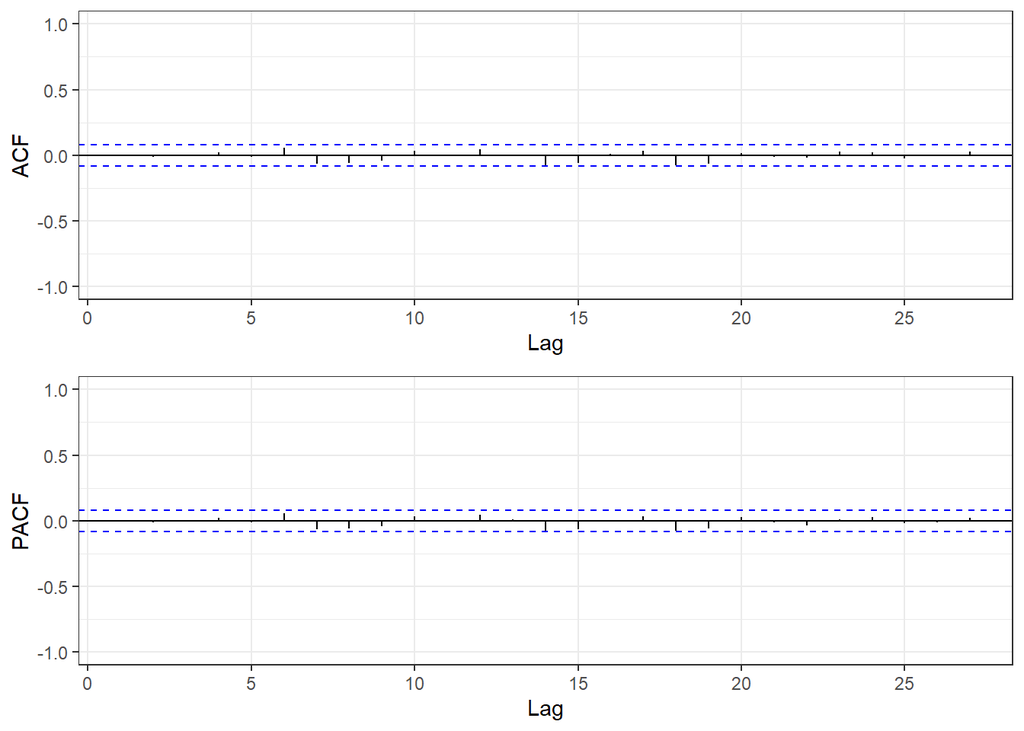

```r
p1 <- ggAcf(res) +
  theme_bw() + ylim(-1,1) +
  theme(plot.title = element_blank())
p2 <- ggPacf(res) +
  theme_bw() +ylim(-1,1) +
  theme(plot.title = element_blank())
grid.arrange(p1, p2, nrow=2)
```

- 위의 3가지 그림을 통해 잔차가 백색잡음의 성질을 만족하고 있다고 판단할 수 있다. 좀 더 명확한 결과를 위해 잔차에 대한 Portmanteau test를 실시해보면 다음과 같다.

```r
LjungBox(fit_final, lags=seq(6,24,3))
```

```
##  lags statistic df   p-value
##     6  2.476581  5 0.7800179
##     9  7.629393  8 0.4704827
##    12  9.483222 11 0.5773803
##    15 15.093655 14 0.3717827
##    18 19.322044 17 0.3103633
##    21 22.048776 20 0.3378698
##    24 22.912653 23 0.4658812
```

- 분석결과, 유의확률의 값이 모두 유의수준 $\alpha=0.05$보다 크기 때문에 잔차가 백색잡음의 성질을 만족한다는 결론을 얻을 수 있다.

### 6) 2007년과 2008년 데이터를 예측하여라.

- 이제까지 적합한 모형은 boxcox 변환을 실시한 이후 적합한 모형이기 때문에 예측값의 경우도 모형을 통해 예측값을 구한 뒤 다시 원래의 상태로 변환해주어야 한다.

```r
mcopper_trans_for <- forecast(fit_final, 12*2)
mcopper_trans_for
```

```
##          Point Forecast    Lo 80    Hi 80    Lo 95    Hi 95
## Jan 2007       19.58077 19.29455 19.86698 19.14304 20.01849
## Feb 2007       19.58077 19.09485 20.06668 18.83762 20.32391
## Mar 2007       19.58077 18.95602 20.20551 18.62530 20.53623
## Apr 2007       19.58077 18.84286 20.31867 18.45224 20.70929
## May 2007       19.58077 18.74488 20.41665 18.30239 20.85914
## Jun 2007       19.58077 18.65724 20.50429 18.16836 20.99317
## Jul 2007       19.58077 18.57723 20.58430 18.04599 21.11555
## Aug 2007       19.58077 18.50314 20.65839 17.93267 21.22886
## Sep 2007       19.58077 18.43382 20.72771 17.82667 21.33486
## Oct 2007       19.58077 18.36846 20.79307 17.72671 21.43482
## Nov 2007       19.58077 18.30645 20.85508 17.63187 21.52966
## Dec 2007       19.58077 18.24732 20.91421 17.54144 21.62009
## Jan 2008       19.58077 18.19071 20.97082 17.45486 21.70668
## Feb 2008       19.58077 18.13631 21.02522 17.37166 21.78987
## Mar 2008       19.58077 18.08388 21.07765 17.29148 21.87005
## Apr 2008       19.58077 18.03324 21.12829 17.21402 21.94751
## May 2008       19.58077 17.98419 21.17734 17.13902 22.02251
## Jun 2008       19.58077 17.93661 21.22492 17.06625 22.09528
## Jul 2008       19.58077 17.89037 21.27116 16.99553 22.16600
## Aug 2008       19.58077 17.84536 21.31617 16.92669 22.23484
## Sep 2008       19.58077 17.80149 21.36004 16.85960 22.30193
## Oct 2008       19.58077 17.75867 21.40286 16.79412 22.36741
## Nov 2008       19.58077 17.71684 21.44469 16.73014 22.43139
## Dec 2008       19.58077 17.67593 21.48560 16.66757 22.49396
```

```r
lam <- BoxCox.lambda(mcopper)
mcopper_return <- (lam*mcopper_trans_for$mean+1)^(1/lam)
mcopper_return
```

```
##           Jan      Feb      Mar      Apr      May      Jun      Jul      Aug
## 2007 3387.143 3387.143 3387.143 3387.143 3387.143 3387.143 3387.143 3387.143
## 2008 3387.143 3387.143 3387.143 3387.143 3387.143 3387.143 3387.143 3387.143
##           Sep      Oct      Nov      Dec
## 2007 3387.143 3387.143 3387.143 3387.143
## 2008 3387.143 3387.143 3387.143 3387.143
```

- 예측결과, 위와 같은 결과를 보여주었으며 이를 그림으로 표현하면 다음과 같다. 다만 이 그림은 boxcox 변환 이후에 대한 예측결과임을 명시하도록 하겠다.

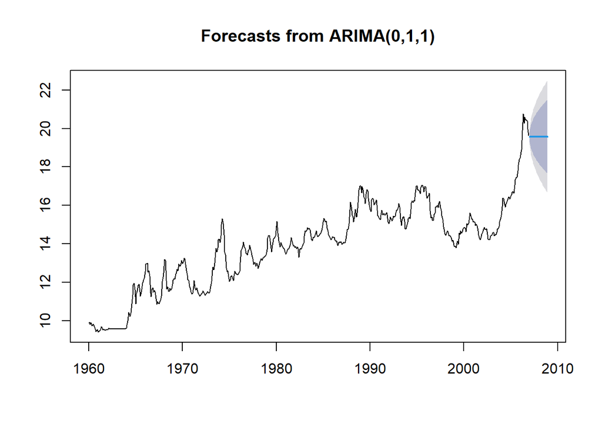

```r
plot(mcopper_trans_for)
```

## 2. 사용할 데이터 : hsales

```r
hsales
```

```
##      Jan Feb Mar Apr May Jun Jul Aug Sep Oct Nov Dec
## 1973  55  60  68  63  65  61  54  52  46  42  37  30
## 1974  37  44  55  53  58  50  48  45  41  34  30  24
## 1975  29  34  44  54  57  51  51  53  46  46  46  39
## 1976  41  53  55  62  55  56  57  59  58  55  49  47
## 1977  57  68  84  81  78  74  64  74  71  63  55  51
## 1978  57  63  75  85  80  77  68  72  68  70  53  50
## 1979  53  58  73  72  68  63  64  68  60  54  41  35
## 1980  43  44  44  36  44  50  55  61  50  46  39  33
## 1981  37  40  49  44  45  38  36  34  28  29  27  29
## 1982  28  29  36  32  36  34  31  36  39  40  39  33
## 1983  44  46  57  59  64  59  51  50  48  51  45  48
## 1984  52  58  63  61  59  58  52  48  53  55  42  38
## 1985  48  55  67  60  65  65  63  61  54  52  51  47
## 1986  55  59  89  84  75  66  57  52  60  54  48  49
## 1987  53  59  73  72  62  58  55  56  52  52  43  37
## 1988  43  55  68  68  64  65  57  59  54  57  43  42
## 1989  52  51  58  60  61  58  62  61  49  51  47  40
## 1990  45  50  58  52  50  50  46  46  38  37  34  29
## 1991  30  40  46  46  47  47  43  46  37  41  39  36
## 1992  48  55  56  53  52  53  52  56  51  48  42  42
## 1993  44  50  60  66  58  59  55  57  57  56  53  51
## 1994  45  58  74  65  65  55  52  59  54  57  45  40
## 1995  47  47  60  58  63  64  64  63  55  54  44
```

### 1) 변수변환이 필요한지를 설명하고, 필요하다면 적절한 변수 변환을 하여라.

- 먼저 본 데이터에 대한 plot을 그려보면 다음과 같다.

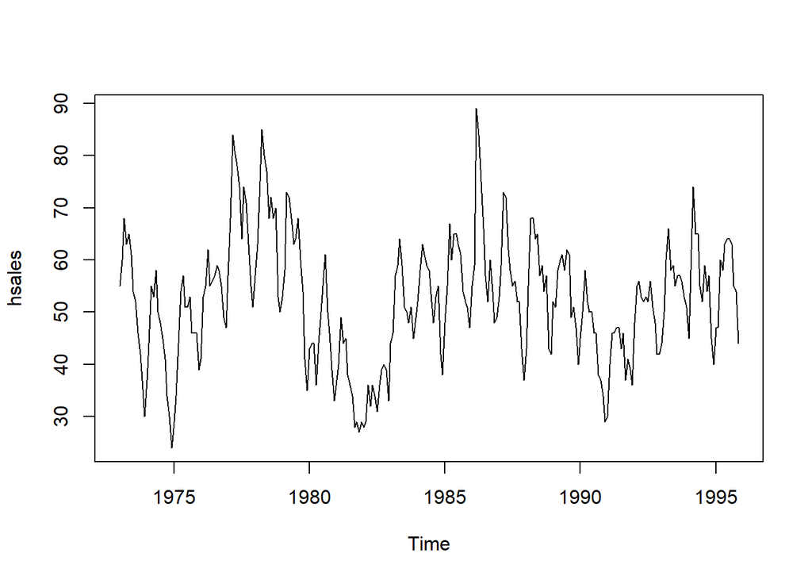

```r
plot(hsales)
```

- plot을 통해서 살펴봤을 때 전체 기간동안 큰 변동성은 없어보인다. 다만 계절성은 존재하는 것으로 판단된다. 따라서 이 경우에 대해서는 변수 변환 없이 분석을 진행하도록 하겠다.

### 2) 데이터가 정상시계열인가? 아니면 적절한 차분을 통해 정상시계열로 변환하여라.

### 3) 모형을 식별하여라. (2개 이상의 모형 고려)(형태 : ARIMA(p.d.q)(P,D,Q)s)

### 4) 3)에서 고려한 모형을 적합하여라. (형태 : ARIMA(p.d.q)(P,D,Q)s, 모수추정값)

### 5) 4)에서 적합된 결과를 이용하여 더 좋은 모형을 선택하여라.

- 본 데이터에 대해 ACF와 PACF를 그려보면 다음과 같다.

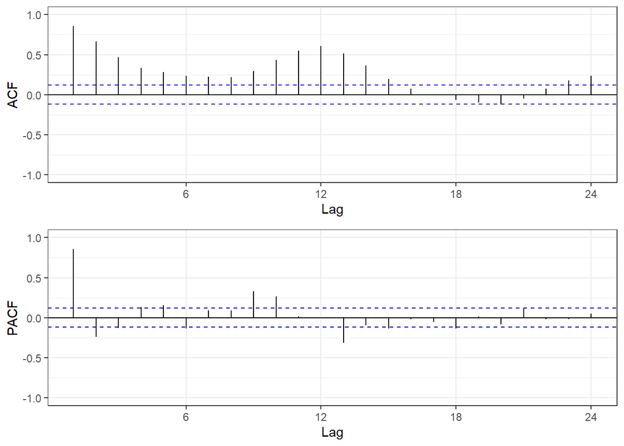

```r
p1 <- ggAcf(hsales) +
  theme_bw() + ylim(-1,1) +
  theme(plot.title = element_blank())
p2 <- ggPacf(hsales) +
  theme_bw() +ylim(-1,1) +
  theme(plot.title = element_blank())
grid.arrange(p1, p2, nrow=2)
```

- 위에 있는 ACF와 PACF를 통해 확실히 계절성이 존재함을 파악할 수 있다. 다만 ACF의 감소하는 속도가 그렇게 빠른것은 아니기 때문에 차분을 실시해야 할 필요가 있다고 보여진다. 단위근이 존재하는지 파악하기 위해 Dickey-Fuller unit root test을 실시하면 다음과 같다. plot을 통해 계절주기가 12라고 보여지므로 시차 1과 12에 대해 검정을 실시한다.

```r
adfTest(hsales, lags = 1, type = "c")
```

```
##
## Title:
##  Augmented Dickey-Fuller Test
##
## Test Results:
##   PARAMETER:
##     Lag Order: 1
##   STATISTIC:
##     Dickey-Fuller: -5.6629
##   P VALUE:
##     0.01
##
## Description:
##  Thu Dec 09 19:54:04 2021 by user: HSY
```

```r
adfTest(hsales, lags = 12, type = "c")
```

```
##
## Title:
##  Augmented Dickey-Fuller Test
##
## Test Results:
##   PARAMETER:
##     Lag Order: 12
##   STATISTIC:
##     Dickey-Fuller: -2.3265
##   P VALUE:
##     0.1907
##
## Description:
##  Thu Dec 09 19:54:04 2021 by user: HSY
```

- 검정결과, 시차 12에 대해 유의확률의 값이 $\alpha=0.05$보다 크므로 시차 12에 대한 계절차분이 필요한 것으로 판단된다. 이에 따라 계절차분을 실시하고 그래프를 그려보면 다음과 같다.

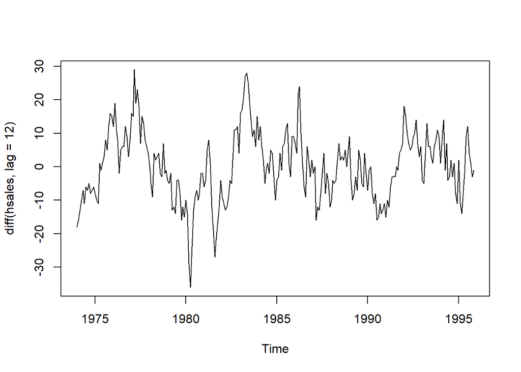

```r
plot(diff(hsales,lag=12))
```

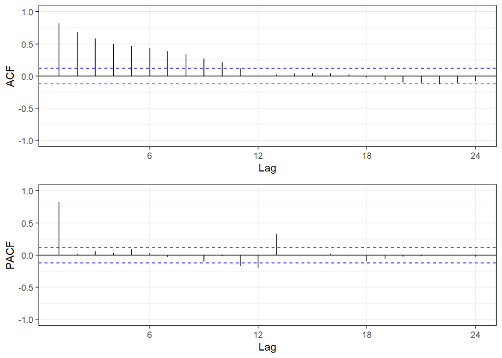

```r
p1 <- ggAcf(diff(hsales,lag=12)) +
  theme_bw() + ylim(-1,1) +
  theme(plot.title = element_blank())
p2 <- ggPacf(diff(hsales,lag=12)) +
  theme_bw() +ylim(-1,1) +
  theme(plot.title = element_blank())
grid.arrange(p1, p2, nrow=2)
```

- 계절차분을 실시한 결과, 정상시계열로 적절하게 변환되었음을 확인할 수 있다. 우선 ACF가 빠른 속도로 감소하고 있고 PACF는 주기 12를 기준으로 빠르게 감소하는 듯한 형태를 보이고 있기 때문에 이를 통해 ARIMA(1,0,0)(0,1,1)_12 모형이 적절하다고 보여진다. 그리고 함수 `auto.arima`를 통해 AIC 기준으로 적절한 모형을 찾아보면 다음과 같다.

```r
auto.arima(hsales, trace=T, ic='aic')
```

```
##
##  Fitting models using approximations to speed things up...
##
##  ARIMA(2,0,2)(1,1,1)[12] with drift         : 1534.443
##  ARIMA(0,0,0)(0,1,0)[12] with drift         : 1922.011
##  ARIMA(1,0,0)(1,1,0)[12] with drift         : 1578.264
##  ARIMA(0,0,1)(0,1,1)[12] with drift         : 1748.344
##  ARIMA(0,0,0)(0,1,0)[12]                    : 1920.035
##  ARIMA(2,0,2)(0,1,1)[12] with drift         : Inf
##  ARIMA(2,0,2)(1,1,0)[12] with drift         : 1582.996
##  ARIMA(2,0,2)(2,1,1)[12] with drift         : 1544.701
##  ARIMA(2,0,2)(1,1,2)[12] with drift         : 1531.308
##  ARIMA(2,0,2)(0,1,2)[12] with drift         : Inf
##  ARIMA(2,0,2)(2,1,2)[12] with drift         : 1540.881
##  ARIMA(1,0,2)(1,1,2)[12] with drift         : 1528.24
##  ARIMA(1,0,2)(0,1,2)[12] with drift         : Inf
##  ARIMA(1,0,2)(1,1,1)[12] with drift         : 1531.413
##  ARIMA(1,0,2)(2,1,2)[12] with drift         : 1537.018
##  ARIMA(1,0,2)(0,1,1)[12] with drift         : Inf
##  ARIMA(1,0,2)(2,1,1)[12] with drift         : 1540.341
##  ARIMA(0,0,2)(1,1,2)[12] with drift         : Inf
##  ARIMA(1,0,1)(1,1,2)[12] with drift         : Inf
##  ARIMA(1,0,3)(1,1,2)[12] with drift         : 1529.162
##  ARIMA(0,0,1)(1,1,2)[12] with drift         : Inf
##  ARIMA(0,0,3)(1,1,2)[12] with drift         : 1605.047
##  ARIMA(2,0,1)(1,1,2)[12] with drift         : Inf
##  ARIMA(2,0,3)(1,1,2)[12] with drift         : Inf
##  ARIMA(1,0,2)(1,1,2)[12]                    : 1527.62
##  ARIMA(1,0,2)(0,1,2)[12]                    : Inf
##  ARIMA(1,0,2)(1,1,1)[12]                    : 1530.12
##  ARIMA(1,0,2)(2,1,2)[12]                    : 1535.059
##  ARIMA(1,0,2)(0,1,1)[12]                    : Inf
##  ARIMA(1,0,2)(2,1,1)[12]                    : 1538.559
##  ARIMA(0,0,2)(1,1,2)[12]                    : 1643.632
##  ARIMA(1,0,1)(1,1,2)[12]                    : 1525.801
##  ARIMA(1,0,1)(0,1,2)[12]                    : Inf
##  ARIMA(1,0,1)(1,1,1)[12]                    : 1528.311
##  ARIMA(1,0,1)(2,1,2)[12]                    : 1535.296
##  ARIMA(1,0,1)(0,1,1)[12]                    : Inf
##  ARIMA(1,0,1)(2,1,1)[12]                    : 1539.744
```

[output cut: 26 more lines]

```
##  ARIMA(1,0,2)(1,1,1)[12] with drift         : Inf
##  ARIMA(1,0,0)(2,1,2)[12]                    : Inf
##  ARIMA(2,0,2)(1,1,1)[12] with drift         : Inf
##  ARIMA(1,0,2)(2,1,2)[12]                    : Inf
##  ARIMA(1,0,1)(2,1,2)[12]                    : Inf
##  ARIMA(1,0,2)(2,1,2)[12] with drift         : Inf
##  ARIMA(1,0,0)(2,1,1)[12]                    : Inf
##  ARIMA(1,0,2)(2,1,1)[12]                    : Inf
##  ARIMA(1,0,1)(2,1,1)[12]                    : Inf
##  ARIMA(1,0,2)(2,1,1)[12] with drift         : Inf
##  ARIMA(2,0,2)(2,1,2)[12] with drift         : Inf
##  ARIMA(2,0,2)(2,1,1)[12] with drift         : Inf
##  ARIMA(1,0,0)(1,1,0)[12] with drift         : 1630.764
##
##  Best model: ARIMA(1,0,0)(1,1,0)[12] with drift
```

```
## Series: hsales
## ARIMA(1,0,0)(1,1,0)[12] with drift
##
## Coefficients:
##          ar1     sar1    drift
##       0.8867  -0.4320  -0.0228
## s.e.  0.0294   0.0569   0.1642
##
## sigma^2 estimated as 27.92:  log likelihood=-811.38
## AIC=1630.76   AICc=1630.92   BIC=1645.05
```

```r
arima(hsales, order = c(1,0,0), seasonal = list(order = c(0,1,1),  period = 12))
```

```
##
## Call:
## arima(x = hsales, order = c(1, 0, 0), seasonal = list(order = c(0, 1, 1), period = 12))
##
## Coefficients:
##          ar1     sma1
##       0.9047  -1.0000
## s.e.  0.0269   0.0619
##
## sigma^2 estimated as 18.89:  log likelihood = -778.94,  aic = 1563.88
```

```r
fit_final <- arima(hsales, order = c(1,0,0), seasonal = list(order = c(0,1,1),  period = 12))
fit_final
```

```
##
## Call:
## arima(x = hsales, order = c(1, 0, 0), seasonal = list(order = c(0, 1, 1), period = 12))
##
## Coefficients:
##          ar1     sma1
##       0.9047  -1.0000
## s.e.  0.0269   0.0619
##
## sigma^2 estimated as 18.89:  log likelihood = -778.94,  aic = 1563.88
```

- 최종으로 선택된 모형을 적합한 결과, 모수의 값이 $\hat{\phi}=0.9047, \hat{\Theta}=1.0000$인 ARIMA(1,0,0)(0,1,1)_12 모형이 적합되었다.

### 6) 5)에서 선택한 모형을 이용하여 잔차검정을 시행하여라.

- 적합한 모형에 대하여 잔차검정을 진행한다면 다음과 같이 할 수 있다. 우선 잔차에 대한 plot과 ACF, PACF를 살펴보면 다음과 같다.

```r
fit_final <- arima(hsales, order = c(1,0,0), seasonal = list(order = c(0,1,1),  period = 12))
fit_final
```

```
##
## Call:
## arima(x = hsales, order = c(1, 0, 0), seasonal = list(order = c(0, 1, 1), period = 12))
##
## Coefficients:
##          ar1     sma1
##       0.9047  -1.0000
## s.e.  0.0269   0.0619
##
## sigma^2 estimated as 18.89:  log likelihood = -778.94,  aic = 1563.88
```

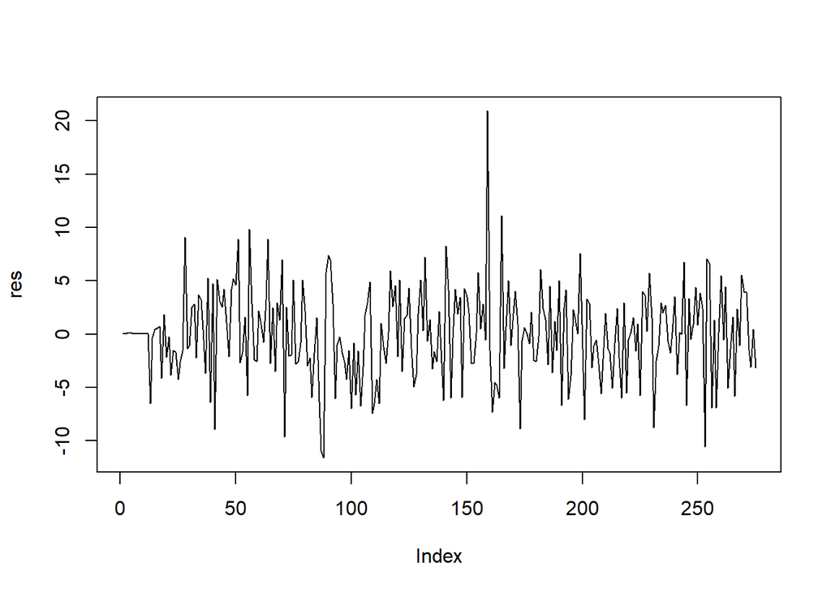

```r
res <- as.numeric(resid(fit_final))
plot(res,type='l')
```

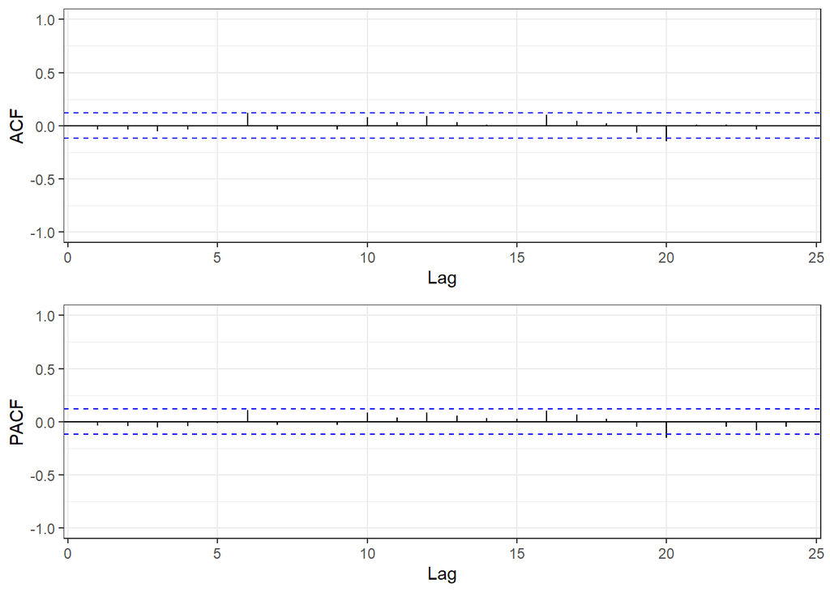

```r
p1 <- ggAcf(res) +
  theme_bw() + ylim(-1,1) +
  theme(plot.title = element_blank())
p2 <- ggPacf(res) +
  theme_bw() +ylim(-1,1) +
  theme(plot.title = element_blank())
grid.arrange(p1, p2, nrow=2)
```

- 위의 3가지 그림을 통해 잔차가 백색잡음의 성질을 만족하고 있다고 판단할 수 있다. 좀 더 명확한 결과를 위해 잔차에 대한 Portmanteau test를 실시해보면 다음과 같다.

```r
LjungBox(fit_final, lags=seq(6,24,3))
```

```
##  lags statistic df   p-value
##     6  5.888298  4 0.2076470
##     9  6.675239  7 0.4634585
##    12 11.484111 10 0.3210645
##    15 11.837731 13 0.5409928
##    18 15.824650 16 0.4652646
##    21 23.563882 19 0.2134165
##    24 23.965008 22 0.3490663
```

- 분석결과, 유의확률의 값이 모두 유의수준 $\alpha=0.05$보다 크기 때문에 잔차가 백색잡음의 성질을 만족한다는 결론을 얻을 수 있다.

### 7) 다음 2년간의 값을 예측하여라.

- 이제까지 적합한 모형을 통해 다음과 같이 이후 2년간의 값을 예측할 수 있다.

```r
hsales_for <- forecast(fit_final, 12*2)
hsales_for
```

```
##          Point Forecast    Lo 80    Hi 80    Lo 95    Hi 95
## Dec 1995       40.46882 34.77471 46.16293 31.76043 49.17721
## Jan 1996       45.85600 38.18015 53.53186 34.11679 57.59521
## Feb 1996       51.62560 42.64923 60.60197 37.89743 65.35378
## Mar 1996       61.87844 51.96408 71.79280 46.71573 77.04115
## Apr 1996       60.74487 50.12458 71.36516 44.50253 76.98720
## May 1996       60.09442 48.92987 71.25898 43.01971 77.16913
## Jun 1996       57.49234 45.90174 69.08294 39.76604 75.21863
## Jul 1996       54.28651 42.35900 66.21402 36.04495 72.52806
## Aug 1996       55.65096 43.45518 67.84674 36.99913 74.30279
## Sep 1996       51.36847 38.95811 63.77882 32.38846 70.34847
## Oct 1996       50.30882 37.72636 62.89127 31.06561 69.55202
## Nov 1996       43.73315 31.01254 56.45377 24.27866 63.18765
## Dec 1996       40.22741 27.36095 53.09387 20.54986 59.90496
## Jan 1997       45.63761 32.65454 58.62068 25.78172 65.49350
## Feb 1997       51.42803 38.34849 64.50757 31.42460 71.43145
## Mar 1997       61.69970 48.54192 74.85748 41.57661 81.82279
## Apr 1997       60.58317 47.36193 73.80441 40.36302 80.80331
## May 1997       59.94814 46.67546 73.22082 39.64933 80.24695
## Jun 1997       57.36000 44.04571 70.67429 36.99755 77.72245
## Jul 1997       54.16678 40.81895 67.51462 33.75303 74.58054
## Aug 1997       55.54265 42.16792 68.91738 35.08776 75.99753
## Sep 1997       51.27048 37.87440 64.66657 30.78294 71.75802
## Oct 1997       50.22017 36.80738 63.63296 29.70708 70.73326
## Nov 1997       43.65296 30.22742 57.07849 23.12038 64.18554
```

- 그리고 예측한 결과를 그래프로 표현하면 다음과 같다.

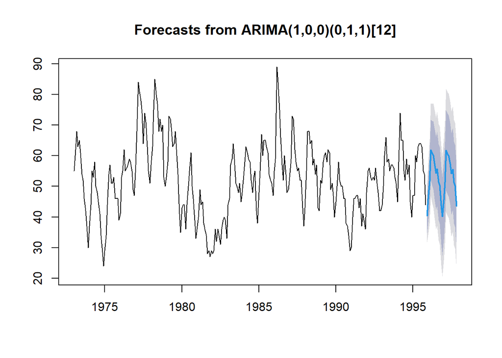

```r
plot(hsales_for)
```

## 3. 사용할 데이터 : ukcars

```r
ukcars
```

```
##         Qtr1    Qtr2    Qtr3    Qtr4
## 1977 330.371 371.051 270.670 343.880
## 1978 358.491 362.822 261.281 240.355
## 1979 325.382 316.700 171.153 257.217
## 1980 298.127 251.464 181.555 192.598
## 1981 245.652 245.526 225.261 238.211
## 1982 257.385 228.461 175.371 226.462
## 1983 266.150 287.251 225.883 265.313
## 1984 272.759 234.134 196.462 205.551
## 1985 291.283 284.422 221.571 250.697
## 1986 253.757 267.016 220.388 277.801
## 1987 283.233 302.072 259.720 297.658
## 1988 306.129 322.106 256.723 341.877
## 1989 356.004 361.540 270.433 311.105
## 1990 326.688 327.059 274.257 367.606
## 1991 346.163 348.211 250.008 292.518
## 1992 343.318 343.429 275.386 329.747
## 1993 364.521 378.448 300.798 331.757
## 1994 362.536 389.133 323.322 391.832
## 1995 421.646 416.823 311.713 381.902
## 1996 422.982 427.722 376.850 458.580
## 1997 436.225 441.487 369.566 450.723
## 1998 462.442 468.232 403.636 413.948
## 1999 460.496 448.932 407.787 469.408
## 2000 494.311 433.240 335.106 378.795
## 2001 387.100 372.395 335.790 397.080
## 2002 449.755 402.252 391.847 385.890
## 2003 424.325 433.280 391.213 408.740
## 2004 445.458 428.202 379.048 394.042
## 2005 432.796
```

### 1) 변수변환이 필요한지를 설명하고, 필요하다면 적절한 변수 변환을 하여라.

- 우선 본 데이터에 대한 plot을 그려보면 다음과 같다.

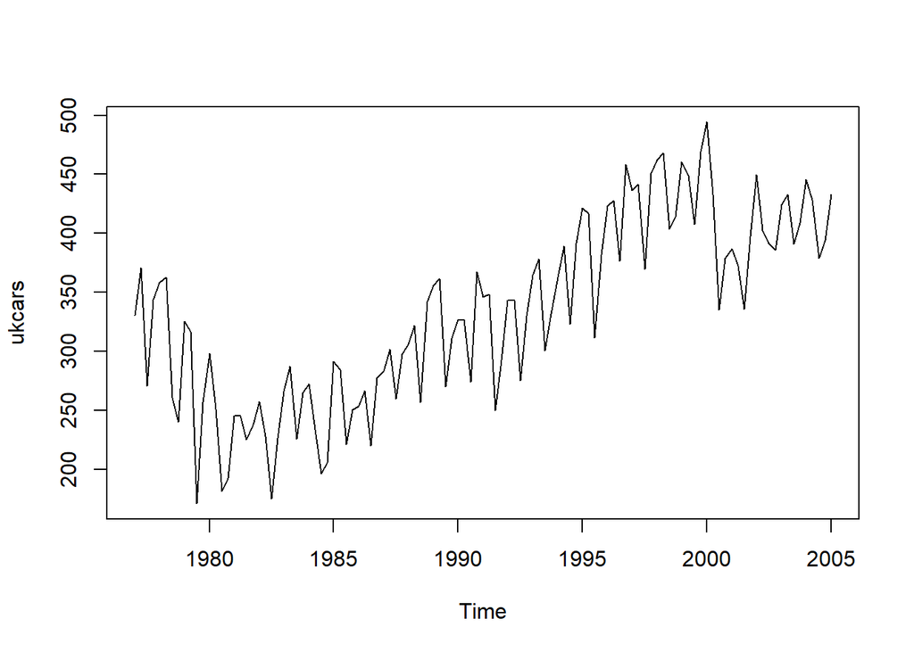

```r
plot(ukcars)
```

- plot을 살펴본 결과 시간이 흘러감에 따라 변동성이 어느정도 나타나는 것으로 보여짐에 따라 log변환을 실시하도록 한다. 이는 다음과 같이 할 수 있다.

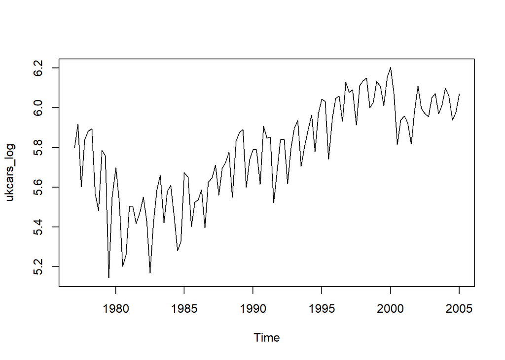

```r
ukcars_log <- log(ukcars)
plot(ukcars_log)
```

### 2) 마지막 2년동안의 데이터는 test 데이터, 나머지는 train 데이터로 분할하여라.

- 변환된 데이터를 다음과 같이 훈련자료와 검증자료로 나눌 수 있다.

```r
dt <- data.table(t = 1:length(ukcars_log),ukcars_log=ukcars_log)
train_dt <- dt[1:108,] ; test_dt <- dt[109:113,]
train <- ts(train_dt[,2], start=c(1977,1), frequency=4)
test <- ts(test_dt[,2], start=c(2004,1), frequency=4)
```

### 3) 이동평균을 이용하여 마지막 2년을 예측하여라.

```r
library(forecast)
library(data.table)
library(ggplot2)
library(lmtest)
library(TTR)
library(tseries)
library(imputeTS)
library(zoo)
library(dplyr)
```

- 1)에서 확인한 plot을 통해서 시계열 자료의 움직임을 바탕으로 판단했을 때 차수 5의 이동평균법을 적용하는 것이 바람직하다고 판단된다. 이를 적용하면 다음과 같은 결과를 얻을 수 있다.

```r
ma(ukcars_log,order=5)
```

```
##          Qtr1     Qtr2     Qtr3     Qtr4
## 1977       NA       NA 5.807930 5.826670
## 1978 5.756521 5.732764 5.721706 5.696916
## 1979 5.546645 5.543510 5.586590 5.535050
## 1980 5.423771 5.447381 5.438180 5.399356
## 1981 5.377348 5.431668 5.489662 5.475152
## 1982 5.407852 5.408915 5.431096 5.453053
## 1983 5.450783 5.533584 5.570787 5.545153
## 1984 5.469176 5.450311 5.468988 5.477362
## 1985 5.466332 5.515087 5.557224 5.539827
## 1986 5.488813 5.534045 5.558450 5.593308
## 1987 5.587767 5.647878 5.667298 5.693020
## 1988 5.660487 5.715456 5.751256 5.784529
## 1989 5.749558 5.787984 5.778895 5.761935
## 1990 5.706673 5.768071 5.789427 5.802187
## 1991 5.748458 5.761350 5.747679 5.746093
## 1992 5.699166 5.754533 5.798544 5.818029
## 1993 5.791520 5.828766 5.847726 5.860793
## 1994 5.829307 5.882186 5.930139 5.958046
## 1995 5.913679 5.946982 5.962281 5.965142
## 1996 5.944979 6.022190 6.048789 6.057352
## 1997 6.028124 6.063925 6.065602 6.079763
## 1998 6.061836 6.084518 6.088809 6.082879
## 1999 6.055235 6.085427 6.120912 6.108709
## 2000 6.050224 6.035474 5.996916 5.940274
## 2001 5.889313 5.923251 5.957593 5.965272
## 2002 5.975455 6.003269 6.016541 6.009077
## 2003 6.003512 6.011954 6.040664 6.042483
## 2004 6.015738 6.017180 6.028617       NA
## 2005       NA
```

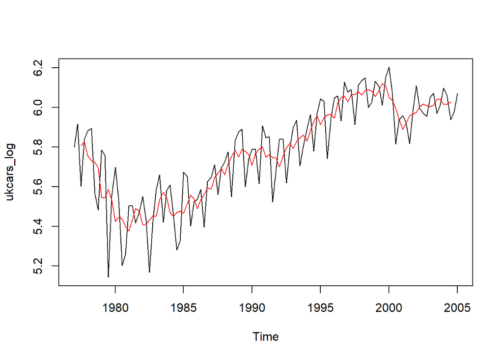

```r
plot(ukcars_log)
lines(ma(ukcars_log,order=5),col='red')
```

- 하지만 이동평균의 차수가 5이기 때문에 마지막 2시점에 대한 예측값은 구할 수 없다는 한계가 있다. 이 점을 감안하여 이에 대한 최종적인 RMSE 값을 계산하면 약 0.0753으로 산출된다.

```r
sqrt(sum((test[1:3]-ma(ukcars_log,order=5)[109:111])^2)/(length(test)-2))
```

```
## [1] 0.07532457
```

### 4) 지수평활법을 이용하여 마지막 2년을 예측하여라.

- 본 시계열 자료는 특정 주기를 바탕으로 상승과 하락을 반복하면서 전체적으로 상승하는 경향을 보이고 있다. 따라서 계절지수평활법을 적용하는 것이 타당하다고 판단된다. 이는 다음과 같이 할 수 있다.

```r
fit1 <- HoltWinters(train)
fit1
```

```
## Holt-Winters exponential smoothing with trend and additive seasonal component.
##
## Call:
## HoltWinters(x = train)
##
## Smoothing parameters:
##  alpha: 0.5378606
##  beta : 0.03866357
##  gamma: 0.2881642
##
## Coefficients:
##            [,1]
## a   6.004830980
## b   0.003218465
## s1  0.098015560
## s2  0.075179256
## s3 -0.074738242
## s4  0.020900043
```

- 이를 바탕으로 마지막 2년에 대한 예측값을 구하면 다음과 같다.

```r
fore1 <- forecast(fit1, h=5)
fore1
```

```
##         Point Forecast    Lo 80    Hi 80    Lo 95    Hi 95
## 2004 Q1       6.106065 5.985429 6.226701 5.921568 6.290562
## 2004 Q2       6.086447 5.948262 6.224632 5.875112 6.297783
## 2004 Q3       5.939748 5.784889 6.094608 5.702911 6.176585
## 2004 Q4       6.038605 5.867652 6.209558 5.777155 6.300055
## 2005 Q1       6.118939 5.925281 6.312597 5.822765 6.415113
```

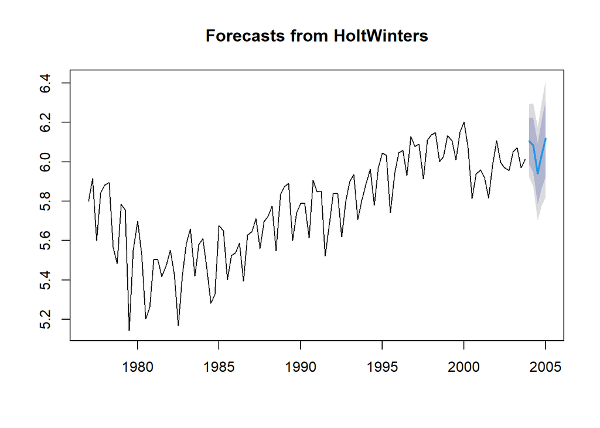

```r
plot(fore1)
```

- 그리고 이 예측값을 이용하여 최종적인 RMSE의 값을 구하면 다음과 같이 약 0.0374로 산출된다.

```r
sqrt(sum((test-fore1$mean)^2)/length(test))
```

```
## [1] 0.03743034
```

### 5) 계절형 ARIMA 모형을 적합하여 마지막 2년을 예측하여라.

- 함수 `auto.arima`를 이용하여 AIC 기준으로 적절한 모형을 선정하면 다음과 같이 계절적인 요소가 포함된 ARIMA(1,0,1)(1,1,1)_4 모형을 제시해준다.

```r
fit2 <- auto.arima(train,trace=T,ic='aic')
```

```
##
##  ARIMA(2,0,2)(1,1,1)[4] with drift         : Inf
##  ARIMA(0,0,0)(0,1,0)[4] with drift         : -122.7163
##  ARIMA(1,0,0)(1,1,0)[4] with drift         : -180.4093
##  ARIMA(0,0,1)(0,1,1)[4] with drift         : -165.6101
##  ARIMA(0,0,0)(0,1,0)[4]                    : -124.2199
##  ARIMA(1,0,0)(0,1,0)[4] with drift         : -146.2746
##  ARIMA(1,0,0)(2,1,0)[4] with drift         : -183.9178
##  ARIMA(1,0,0)(2,1,1)[4] with drift         : -186.4454
##  ARIMA(1,0,0)(1,1,1)[4] with drift         : -188.4436
##  ARIMA(1,0,0)(0,1,1)[4] with drift         : -187.9316
##  ARIMA(1,0,0)(1,1,2)[4] with drift         : -186.8576
##  ARIMA(1,0,0)(0,1,2)[4] with drift         : -188.376
##  ARIMA(1,0,0)(2,1,2)[4] with drift         : -184.9355
##  ARIMA(0,0,0)(1,1,1)[4] with drift         : -139.5218
##  ARIMA(2,0,0)(1,1,1)[4] with drift         : -189.8721
##  ARIMA(2,0,0)(0,1,1)[4] with drift         : -188.4258
##  ARIMA(2,0,0)(1,1,0)[4] with drift         : -180.4789
##  ARIMA(2,0,0)(2,1,1)[4] with drift         : -188.2266
##  ARIMA(2,0,0)(1,1,2)[4] with drift         : -189.1057
##  ARIMA(2,0,0)(0,1,0)[4] with drift         : -144.8818
##  ARIMA(2,0,0)(0,1,2)[4] with drift         : -189.3958
##  ARIMA(2,0,0)(2,1,0)[4] with drift         : -183.3128
##  ARIMA(2,0,0)(2,1,2)[4] with drift         : -187.1062
##  ARIMA(3,0,0)(1,1,1)[4] with drift         : -189.1517
##  ARIMA(2,0,1)(1,1,1)[4] with drift         : -189.6935
##  ARIMA(1,0,1)(1,1,1)[4] with drift         : -191.1595
##  ARIMA(1,0,1)(0,1,1)[4] with drift         : -188.9234
##  ARIMA(1,0,1)(1,1,0)[4] with drift         : -181.1015
##  ARIMA(1,0,1)(2,1,1)[4] with drift         : -189.9126
##  ARIMA(1,0,1)(1,1,2)[4] with drift         : -190.8238
##  ARIMA(1,0,1)(0,1,0)[4] with drift         : -144.6325
##  ARIMA(1,0,1)(0,1,2)[4] with drift         : -190.3594
##  ARIMA(1,0,1)(2,1,0)[4] with drift         : -183.7982
##  ARIMA(1,0,1)(2,1,2)[4] with drift         : -188.8509
##  ARIMA(0,0,1)(1,1,1)[4] with drift         : -165.3682
##  ARIMA(1,0,2)(1,1,1)[4] with drift         : -189.7395
##  ARIMA(0,0,2)(1,1,1)[4] with drift         : -170.0945
##  ARIMA(1,0,1)(1,1,1)[4]                    : -192.8815
##  ARIMA(1,0,1)(0,1,1)[4]                    : -189.6145
##  ARIMA(1,0,1)(1,1,0)[4]                    : -182.8366
##  ARIMA(1,0,1)(2,1,1)[4]                    : -191.4407
##  ARIMA(1,0,1)(1,1,2)[4]                    : -192.4652
##  ARIMA(1,0,1)(0,1,0)[4]                    : -146.3891
##  ARIMA(1,0,1)(0,1,2)[4]                    : -192.109
##  ARIMA(1,0,1)(2,1,0)[4]                    : -185.5182
##  ARIMA(1,0,1)(2,1,2)[4]                    : -190.4687
##  ARIMA(0,0,1)(1,1,1)[4]                    : -166.223
##  ARIMA(1,0,0)(1,1,1)[4]                    : -189.2923
##  ARIMA(2,0,1)(1,1,1)[4]                    : -191.5466
##  ARIMA(1,0,2)(1,1,1)[4]                    : -191.5947
##  ARIMA(0,0,0)(1,1,1)[4]                    : -140.4702
##  ARIMA(0,0,2)(1,1,1)[4]                    : -170.6427
##  ARIMA(2,0,0)(1,1,1)[4]                    : -191.1878
##  ARIMA(2,0,2)(1,1,1)[4]                    : -189.596
##
##  Best model: ARIMA(1,0,1)(1,1,1)[4]
```

```r
fit2
```

```
## Series: train
## ARIMA(1,0,1)(1,1,1)[4]
##
## Coefficients:
##          ar1      ma1     sar1     sma1
##       0.9280  -0.3560  -0.3035  -0.6627
## s.e.  0.0545   0.1311   0.1263   0.1229
##
## sigma^2 estimated as 0.008352:  log likelihood=101.44
## AIC=-192.88   AICc=-192.27   BIC=-179.66
```

- 이를 바탕으로 마지막 2년에 대한 예측값을 구하면 다음과 같다.

```r
fore2 <- forecast(fit2, 5)
fore2
```

```
##         Point Forecast    Lo 80    Hi 80    Lo 95    Hi 95
## 2004 Q1       6.106187 5.989070 6.223304 5.927072 6.285302
## 2004 Q2       6.041535 5.906609 6.176461 5.835183 6.247886
## 2004 Q3       5.925993 5.777430 6.074555 5.698785 6.153200
## 2004 Q4       6.012982 5.853606 6.172357 5.769238 6.256725
## 2005 Q1       6.091472 5.922038 6.260906 5.832345 6.350599
```

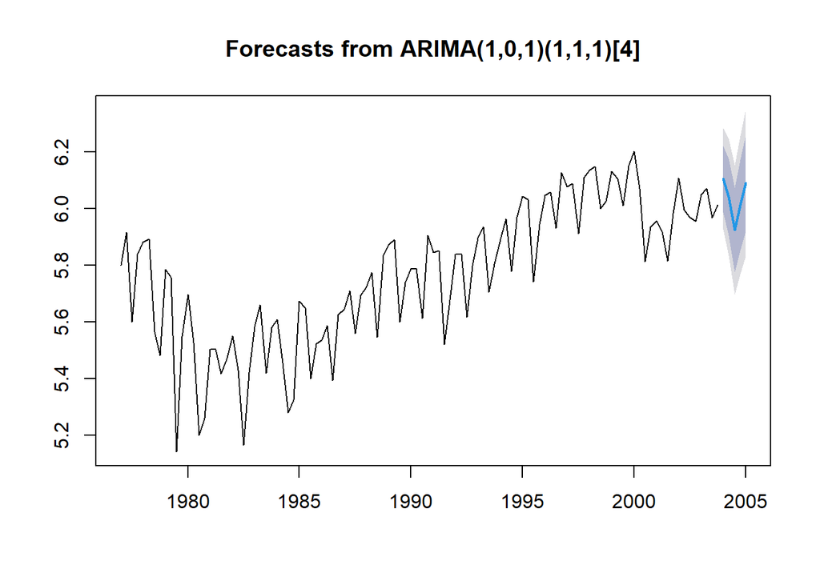

```r
plot(fore2)
```

- 그리고 이 예측값을 이용하여 최종적인 RMSE의 값을 구하면 다음과 같이 약 0.0214로 산출된다.

```r
sqrt(sum((test-fore2$mean)^2)/length(test))
```

```
## [1] 0.02143001
```

### 6) 예측값과 실제값을 이용하여 3)-5) 모형 중 가장 좋은 모형을 선택하여라.

- 3가지 모형을 통해 예측값을 구하고 이에 대한 RMSE를 계산한 결과 계절형 ARIMA 모형에 대한 RMSE의 값이 가장 작게 산출되었다. 이에 따라 계절형 ARIMA 모형을 가장 좋은 모형으로 선택할 수 있다.